# The weight of the ductular reaction in alcohol liver disease

Lluís Revilla

2016-12-07

# 1 Alcohol liver disease

## 1.1 Load disease expression

The expression data is provided as counts in a tab separate value format. In another file there is the phenoData associated to the samples.

```r
count <- read.delim("../data/ALD_ramon/NGS_AHsteps.expr.counts.tsv",
                    row.names = 1)
phenoData <- read.csv("../data/ALD_ramon/NGS_AHsteps.design.csv", row.names = 1)
```

First we will explore a little bit the data, in case we need to correct something:

```r
library("geneplotter")
summary(phenoData)
```

```
##      Group         Sample.id        L                               G
##  E      :12   INTEAM_A01: 1   E      :12   Early.ASH                 :12
##  C      :11   INTEAM_A02: 1   C      :11   AH.Non.severe             :11
##  D      :10   INTEAM_A03: 1   D      :10   Explants.from.AH          :10
##  I      :10   INTEAM_A04: 1   I      :10   Normal.livers             :10
##  A      : 9   INTEAM_A05: 1   A      : 9   AH.Severe.-.non-responders: 9
##  B      : 9   INTEAM_A06: 1   B      : 9   AH.Severe.-.responders    : 9
##  (Other):27   (Other)   :82   (Other):27   (Other)                   :27
```

```r
phenoData
```

```
##     Group  Sample.id L                          G
## A01     A INTEAM_A01 A     AH.Severe.-.responders
## A02     A INTEAM_A02 A     AH.Severe.-.responders
## A03     A INTEAM_A03 A     AH.Severe.-.responders
## A04     A INTEAM_A04 A     AH.Severe.-.responders
## A05     A INTEAM_A05 A     AH.Severe.-.responders
## A06     A INTEAM_A06 A     AH.Severe.-.responders
## A07     A INTEAM_A07 A     AH.Severe.-.responders
## A08     A INTEAM_A08 A     AH.Severe.-.responders
## A09     A INTEAM_A09 A     AH.Severe.-.responders
## B10     B INTEAM_B10 B AH.Severe.-.non-responders
## B11     B INTEAM_B11 B AH.Severe.-.non-responders
## B12     B INTEAM_B12 B AH.Severe.-.non-responders
## B13     B INTEAM_B13 B AH.Severe.-.non-responders
## B14     B INTEAM_B14 B AH.Severe.-.non-responders
## B15     B INTEAM_B15 B AH.Severe.-.non-responders
## B16     B INTEAM_B16 B AH.Severe.-.non-responders
## B17     B INTEAM_B17 B AH.Severe.-.non-responders
## B18     B INTEAM_B18 B AH.Severe.-.non-responders
## C19     C INTEAM_C19 C              AH.Non.severe
## C20     C INTEAM_C20 C              AH.Non.severe
## C21     C INTEAM_C21 C              AH.Non.severe
## C22     C INTEAM_C22 C              AH.Non.severe
## C23     C INTEAM_C23 C              AH.Non.severe
## C24     C INTEAM_C24 C              AH.Non.severe
## C25     C INTEAM_C25 C              AH.Non.severe
## C26     C INTEAM_C26 C              AH.Non.severe
## C27     C INTEAM_C27 C              AH.Non.severe
## C28     C INTEAM_C28 C              AH.Non.severe
## C29     C INTEAM_C29 C              AH.Non.severe
## D30     D INTEAM_D30 D           Explants.from.AH
## D31     D INTEAM_D31 D           Explants.from.AH
## D32     D INTEAM_D32 D           Explants.from.AH
## D34     D INTEAM_D34 D           Explants.from.AH
## D35     D INTEAM_D35 D           Explants.from.AH
## D36     D INTEAM_D36 D           Explants.from.AH
## D37     D INTEAM_D37 D           Explants.from.AH
## D38     D INTEAM_D38 D           Explants.from.AH
## D39     D INTEAM_D39 D           Explants.from.AH
## D40     D INTEAM_D40 D           Explants.from.AH
```

[output cut: 34 more lines]

```
## H76     H INTEAM_H76 H      Compensated.cirrhosis
## H77     H INTEAM_H77 H      Compensated.cirrhosis
## H78     H INTEAM_H78 H      Compensated.cirrhosis
## H79     H INTEAM_H79 H      Compensated.cirrhosis
## H80     H INTEAM_H80 H      Compensated.cirrhosis
## I89     I INTEAM_I89 I              Normal.livers
## I90     I INTEAM_I90 I              Normal.livers
## I91     I INTEAM_I91 I              Normal.livers
## I92     I INTEAM_I92 I              Normal.livers
## I93     I INTEAM_I93 I              Normal.livers
## I94     I INTEAM_I94 I              Normal.livers
## I95     I INTEAM_I95 I              Normal.livers
## I96     I INTEAM_I96 I              Normal.livers
## I97     I INTEAM_I97 I              Normal.livers
## I98     I INTEAM_I98 I              Normal.livers
```

```r
count[1:5, 1:5]
```

```
##           A01 A02 A03 A04 A05
## DDX11L1     3   8   0   2   2
## WASH7P     43  82 104  66  82
## MIR6859-3   0   0   0   0   0
## MIR6859-4   0   0   0   0   0
## MIR6859-1   0   0   0   0   0
```

So we will delete two colums that has the same information as the column G. And we will use more easily readable names:

```r
phenoData <- phenoData[, c("Sample.id", "G")]
colnames(phenoData) <- c("Sample", "Status")
levels(phenoData$Status) <- c("AH", "Non-responders", "Responders", "C.Comp",
                              "ASH", "Explants", "HCV", "NASH", "Normal")
phenoData
```

```
##         Sample         Status
## A01 INTEAM_A01     Responders
## A02 INTEAM_A02     Responders
## A03 INTEAM_A03     Responders
## A04 INTEAM_A04     Responders
## A05 INTEAM_A05     Responders
## A06 INTEAM_A06     Responders
## A07 INTEAM_A07     Responders
## A08 INTEAM_A08     Responders
## A09 INTEAM_A09     Responders
## B10 INTEAM_B10 Non-responders
## B11 INTEAM_B11 Non-responders
## B12 INTEAM_B12 Non-responders
## B13 INTEAM_B13 Non-responders
## B14 INTEAM_B14 Non-responders
## B15 INTEAM_B15 Non-responders
## B16 INTEAM_B16 Non-responders
## B17 INTEAM_B17 Non-responders
## B18 INTEAM_B18 Non-responders
## C19 INTEAM_C19             AH
## C20 INTEAM_C20             AH
## C21 INTEAM_C21             AH
## C22 INTEAM_C22             AH
## C23 INTEAM_C23             AH
## C24 INTEAM_C24             AH
## C25 INTEAM_C25             AH
## C26 INTEAM_C26             AH
## C27 INTEAM_C27             AH
## C28 INTEAM_C28             AH
## C29 INTEAM_C29             AH
## D30 INTEAM_D30       Explants
## D31 INTEAM_D31       Explants
## D32 INTEAM_D32       Explants
## D34 INTEAM_D34       Explants
## D35 INTEAM_D35       Explants
## D36 INTEAM_D36       Explants
## D37 INTEAM_D37       Explants
## D38 INTEAM_D38       Explants
## D39 INTEAM_D39       Explants
## D40 INTEAM_D40       Explants
```

[output cut: 34 more lines]

```
## H76 INTEAM_H76         C.Comp
## H77 INTEAM_H77         C.Comp
## H78 INTEAM_H78         C.Comp
## H79 INTEAM_H79         C.Comp
## H80 INTEAM_H80         C.Comp
## I89 INTEAM_I89         Normal
## I90 INTEAM_I90         Normal
## I91 INTEAM_I91         Normal
## I92 INTEAM_I92         Normal
## I93 INTEAM_I93         Normal
## I94 INTEAM_I94         Normal
## I95 INTEAM_I95         Normal
## I96 INTEAM_I96         Normal
## I97 INTEAM_I97         Normal
## I98 INTEAM_I98         Normal
```

However we are only interested on those related to alcohhol disease, so we need to subset them:

```r
alcohol <- !phenoData$Status %in% c("HCV", "NASH", "Explants")
phenoData <- phenoData[alcohol, ]
count <- count[, colnames(count) %in% rownames(phenoData)]
```

```r
library("edgeR")
```

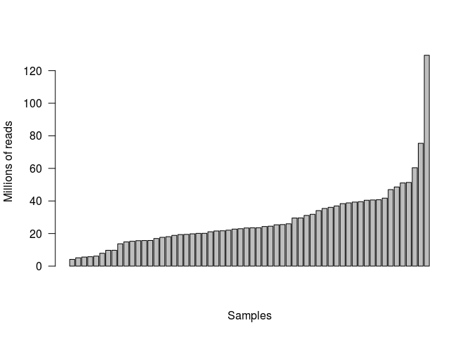

```r
dge <- DGEList(counts = count)
ord <- order(dge$sample$lib.size)
barplot(dge$sample$lib.size[ord]/1e6, las = 1, ylab = "Millions of reads",
        xlab = "Samples")
```

```r
dge <- calcNormFactors(dge)
```

We can normalize the data to counts per millon of reads taking into account that we know the normalized library size:

```r
expression <- cpm(dge, normalized.lib.sizes = TRUE, log = TRUE, prior.count = 3)
```

## 1.2 Check quality pre-normalizations

We can observe the quality of the samples with a boxplot and the density of expressions:

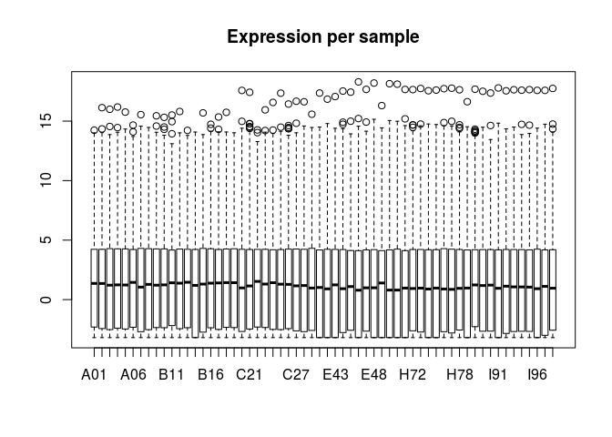

```r
boxplot(expression, main = "Expression per sample")
```

```r
multidensity(expression, main = "Densities of expression", legend = NULL)
```

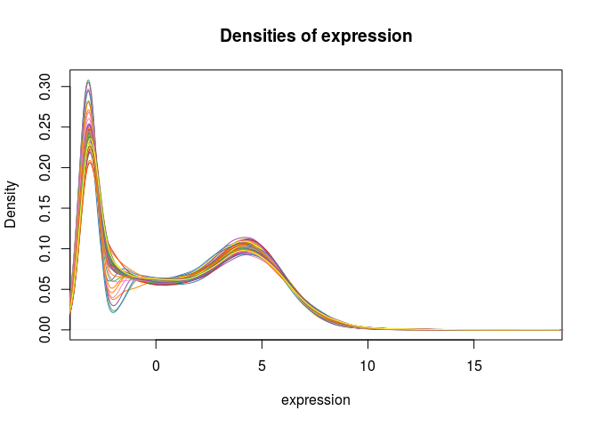

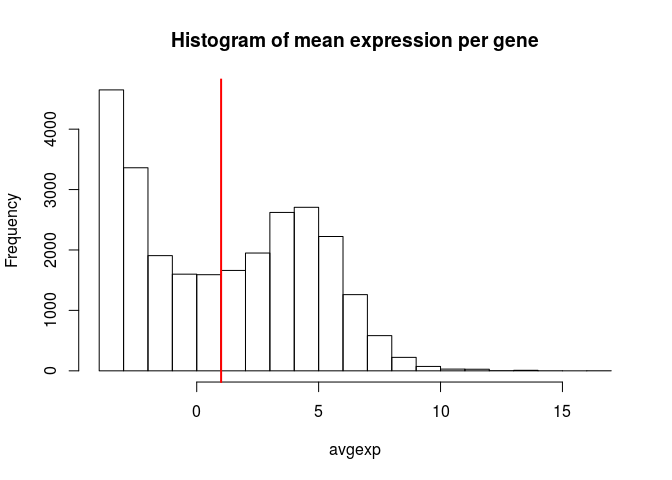

```r
avgexp <- rowMeans(expression)
hist(avgexp, main = "Histogram of mean expression per gene")
abline(v = 1, col = "red", lwd = 2)
```

There is a lot of differences between samples on the low expressed genes. We should filter those genes that are below 1, as they are unreliable.

```r
expression <- expression[avgexp > 1, ]
multidensity(expression, main = "Densities of expression", legend = NULL)
```

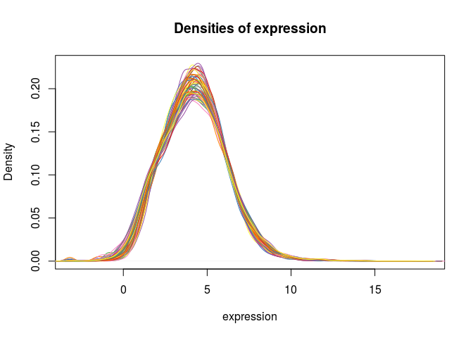

Now the distribution of the expression between samples is much more comparable.

To work easier with the data I proceed to create an ExpressionSet

```r
library("Biobase")
library("AnnotationDbi")
ALD <- ExpressionSet(as.matrix(expression))
phenoData(ALD) <- AnnotatedDataFrame(phenoData)
ALD
```

```
## ExpressionSet (storageMode: lockedEnvironment)
## assayData: 13366 features, 60 samples
##   element names: exprs
## protocolData: none
## phenoData
##   rowNames: A01 A02 ... I98 (60 total)
##   varLabels: Sample Status
##   varMetadata: labelDescription
## featureData: none
## experimentData: use 'experimentData(object)'
## Annotation:
```

## 1.3 Check the normalizations applied

We take advantatge of the plotMDS function of limma package to plot the MDS of the samples, to see how close are between them.

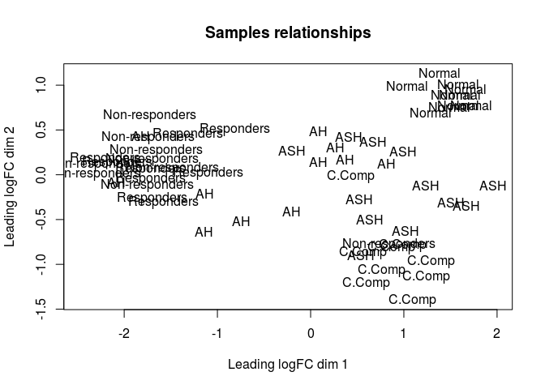

```r
library("limma")
plotMDS(ALD, labels = phenoData(ALD)$Status, main = "Samples relationships")
```

We can see that they are clearly separated in two groups, but some samples like the Alcohol Hepatitis samples are on both sites of the first dimension. We can also observe that the cirrhosis compensated samples are closer to the normal or healthy samples.

## 1.4 Design

The design we will use to find the differentially expressed genes is the following:

```r
# To ensure sintactically valid names
names <- make.names(levels(droplevels(phenoData(ALD)$Status)))
design <- sapply(names, function(x){
  x <- ifelse(x == "Non.responders", "Non-responders", x)
  ifelse(phenoData(ALD)$Status == x, 1, 0)
})
rownames(design) <- rownames(phenoData(ALD))
design
```

```
##     AH Non.responders Responders C.Comp ASH Normal
## A01  0              0          1      0   0      0
## A02  0              0          1      0   0      0
## A03  0              0          1      0   0      0
## A04  0              0          1      0   0      0
## A05  0              0          1      0   0      0
## A06  0              0          1      0   0      0
## A07  0              0          1      0   0      0
## A08  0              0          1      0   0      0
## A09  0              0          1      0   0      0
## B10  0              1          0      0   0      0
## B11  0              1          0      0   0      0
## B12  0              1          0      0   0      0
## B13  0              1          0      0   0      0
## B14  0              1          0      0   0      0
## B15  0              1          0      0   0      0
## B16  0              1          0      0   0      0
## B17  0              1          0      0   0      0
## B18  0              1          0      0   0      0
## C19  1              0          0      0   0      0
## C20  1              0          0      0   0      0
## C21  1              0          0      0   0      0
## C22  1              0          0      0   0      0
## C23  1              0          0      0   0      0
## C24  1              0          0      0   0      0
## C25  1              0          0      0   0      0
## C26  1              0          0      0   0      0
## C27  1              0          0      0   0      0
## C28  1              0          0      0   0      0
## C29  1              0          0      0   0      0
## E41  0              0          0      0   1      0
## E42  0              0          0      0   1      0
## E43  0              0          0      0   1      0
## E44  0              0          0      0   1      0
## E45  0              0          0      0   1      0
## E46  0              0          0      0   1      0
## E47  0              0          0      0   1      0
## E48  0              0          0      0   1      0
## E49  0              0          0      0   1      0
## E50  0              0          0      0   1      0
## E51  0              0          0      0   1      0
## E52  0              0          0      0   1      0
## H72  0              0          0      1   0      0
## H73  0              0          0      1   0      0
## H74  0              0          0      1   0      0
## H75  0              0          0      1   0      0
## H76  0              0          0      1   0      0
## H77  0              0          0      1   0      0
## H78  0              0          0      1   0      0
## H79  0              0          0      1   0      0
## H80  0              0          0      1   0      0
## I89  0              0          0      0   0      1
## I90  0              0          0      0   0      1
## I91  0              0          0      0   0      1
## I92  0              0          0      0   0      1
## I93  0              0          0      0   0      1
## I94  0              0          0      0   0      1
## I95  0              0          0      0   0      1
## I96  0              0          0      0   0      1
## I97  0              0          0      0   0      1
## I98  0              0          0      0   0      1
```

As you can see each group has its own colum to increase the power to the model, and to allow for more informative contrasts.

```r
refact <- function(x){
  if (x == "Normal") {
    0
  } else if ( x == "ASH") {
    1
  } else if (x == "C.Comp") {
    2
  } else if (x == "AH") {
    4
  } else if (x == "Responders") {
    5
  } else if (x == "Non-responders") {
    5
  } else {
    stop("Unexpected level")
  }
}
design2 <- sapply(as.character(phenoData(ALD)$Status), refact)
design2 <- as.matrix(design2)
colnames(design2) <- "Progression"
rownames(design2) <- rownames(phenoData(ALD))
design2
```

```
##     Progression
## A01           5
## A02           5
## A03           5
## A04           5
## A05           5
## A06           5
## A07           5
## A08           5
## A09           5
## B10           5
## B11           5
## B12           5
## B13           5
## B14           5
## B15           5
## B16           5
## B17           5
## B18           5
## C19           4
## C20           4
## C21           4
## C22           4
## C23           4
## C24           4
## C25           4
## C26           4
## C27           4
## C28           4
## C29           4
## E41           1
## E42           1
## E43           1
## E44           1
## E45           1
## E46           1
## E47           1
## E48           1
## E49           1
## E50           1
## E51           1
## E52           1
## H72           2
## H73           2
## H74           2
## H75           2
## H76           2
## H77           2
## H78           2
## H79           2
## H80           2
## I89           0
## I90           0
## I91           0
## I92           0
## I93           0
## I94           0
## I95           0
## I96           0
## I97           0
## I98           0
```

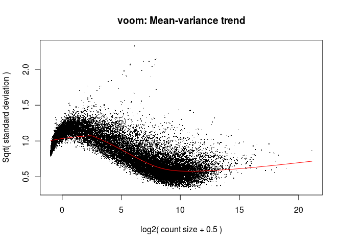

```r
v <- voom(dge, design, plot = TRUE)
```

We fit each design with the expression of the alcoholic liver disease:

```r
fit <- lmFit(v$E, design)
fit.2 <- lmFit(v$E, design2)
```

## 1.5 Contrasts

We are interested in several comparisons, in the first design:

```r
contrasts <- makeContrasts("ASHvsNormal" = ASH - Normal,
                          "CirrhosisVsNormal" = C.Comp - Normal,
                          "AHvsNormal" = AH - Normal,
                          "RespondersVsNormal" = Responders - Normal,
                          "Non-respondersVsNormal" = Non.responders - Normal,

                          # Assuming that some status are similar
                          "SevereVsNormal" = (Responders + Non.responders)/2 - Normal,

                          "RespondersVsNon-responders" = Responders - Non.responders,

                          "CirrhosisVsASH" = C.Comp - ASH,
                          "AHvsCirrhosis" = AH - C.Comp,

                          "Non-respondersVsAH" = Non.responders - AH,
                          "RespondersVsAH" = Responders - AH,
                          "SevereVsHepatitis" = (Non.responders + Responders)/2 - AH,

                          levels = design)
contrasts
```

```
##                 Contrasts
## Levels           ASHvsNormal CirrhosisVsNormal AHvsNormal
##   AH                       0                 0          1
##   Non.responders           0                 0          0
##   Responders               0                 0          0
##   C.Comp                   0                 1          0
##   ASH                      1                 0          0
##   Normal                  -1                -1         -1
##                 Contrasts
## Levels           RespondersVsNormal Non-respondersVsNormal SevereVsNormal
##   AH                              0                      0            0.0
##   Non.responders                  0                      1            0.5
##   Responders                      1                      0            0.5
##   C.Comp                          0                      0            0.0
##   ASH                             0                      0            0.0
##   Normal                         -1                     -1           -1.0
##                 Contrasts
## Levels           RespondersVsNon-responders CirrhosisVsASH AHvsCirrhosis
##   AH                                      0              0             1
##   Non.responders                         -1              0             0
##   Responders                              1              0             0
##   C.Comp                                  0              1            -1
##   ASH                                     0             -1             0
##   Normal                                  0              0             0
##                 Contrasts
## Levels           Non-respondersVsAH RespondersVsAH SevereVsHepatitis
##   AH                             -1             -1              -1.0
##   Non.responders                  1              0               0.5
##   Responders                      0              1               0.5
##   C.Comp                          0              0               0.0
##   ASH                             0              0               0.0
##   Normal                          0              0               0.0
```

Given those comparisons of interest we now evaluate the results:

```r
fit2 <- contrasts.fit(fit, contrasts)
fit2 <- eBayes(fit2, proportion = 0.1)
results <- decideTests(fit2, adjust.method = "fdr", lfc = log2(2))
summary(results)
```

```
##    ASHvsNormal CirrhosisVsNormal AHvsNormal RespondersVsNormal
## -1        1094              1284       1440               2051
## 0        18587             22543      22182              20381
## 1         6792              2646       2851               4041
##    Non-respondersVsNormal SevereVsNormal RespondersVsNon-responders
## -1                   2178           2219                          0
## 0                   19086          19299                      26473
## 1                    5209           4955                          0
##    CirrhosisVsASH AHvsCirrhosis Non-respondersVsAH RespondersVsAH
## -1           3665           828                253            136
## 0           22288         24236              26110          26216
## 1             520          1409                110            121
##    SevereVsHepatitis
## -1               262
## 0              25954
## 1                257
```

```r
fit2.2 <- eBayes(fit.2, proportion = 0.95)
results2 <- decideTests(fit2.2)
summary(results2)
```

```
##    Progression
## -1       11021
## 0         1108
## 1        14344
```

We can observe the quality of the t-values over the teoretical quantiles to observe if there is any assumption about the eBayes fitting which doesn’t holds. Note that I already modified the expected proportion of genes in the call to eBayes:

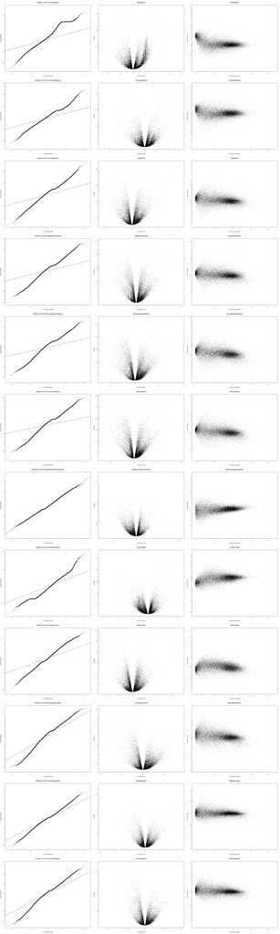

```r
par(mfrow = c(ncol(results), 3))
out <- sapply(colnames(results), function(x){
  qqt(fit2$t[, x], df = fit2$df.total, main = paste("Student's t Q-Q Plot of", x))
  abline(0, 1)
  volcanoplot(fit2, coef = x, main = x)
  plotMD(fit2, coef = x, main = x)
})
```

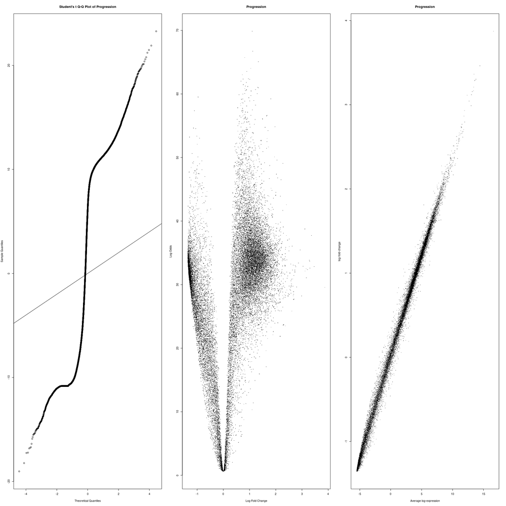

```r
par(mfrow = c(ncol(results2), 3))
out <- sapply(colnames(results2), function(x){
  qqt(fit2.2$t[, x], df = fit2.2$df.total, main = paste("Student's t Q-Q Plot of", x))
  abline(0, 1)
  volcanoplot(fit2.2, coef = x, main = paste(x))
  plotMD(fit2.2, coef = x, main = x)
})
```

Here we can see on the last plot that the exprsesion of the genes show a bimodal distribution in the progression of the dissease. Which seems to confirm that at one point it descompensates and has a very bad prognossis.

## 1.6 Store data

It is a good idea to store the data, not only the program of your analysis, so here I go:

```r
save(fit, fit2, fit2.2, fit.2, design, design2, ALD, contrasts, file = "ALD.RData")
```

## 1.7 Differentially expressed genes

We can plot the top 2000 genes with the highest absolute value of log fold-change in each :

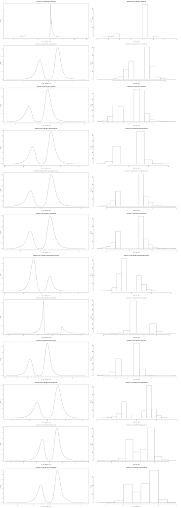

```r
par(mfrow = c(ncol(results), 2))
out <- sapply(colnames(results), function(x) {
  tt.ALD <- topTable(fit2, coef = x, sort.by = "logFC", number = Inf)
  tt.ALD <- tt.ALD[order(-abs(tt.ALD$logFC)), ]
  plot(density(tt.ALD[1:2000, "logFC"]),
       main = paste("Distribution of the top 2000 DEG in", x))
  hist(tt.ALD[1:2000, "logFC"],
       main = paste("Distribution of the top 2000 DEG in", x))
})
```

For the progression model we can plot it too:

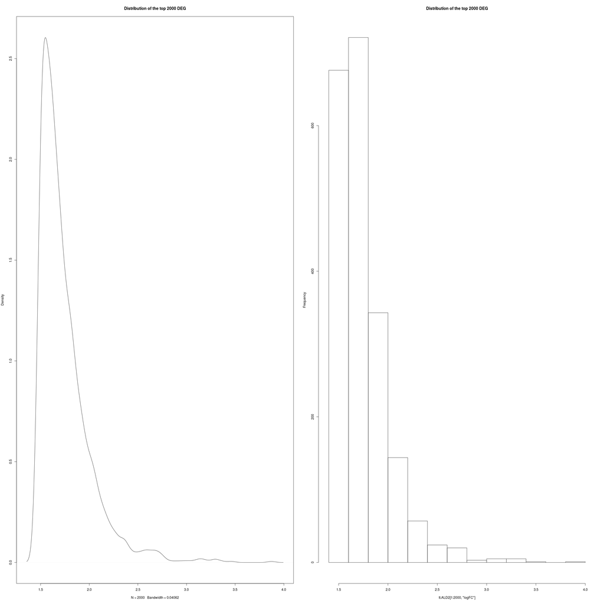

```r
par(mfrow = c(1, 2))
tt.ALD2 <- topTable(fit2.2, coef = "Progression", sort.by = "logFC", number = Inf)
tt.ALD2 <- tt.ALD2[order(-abs(tt.ALD2$logFC)), ]
plot(density(tt.ALD2[1:2000, "logFC"]), main = "Distribution of the top 2000 DEG")
hist(tt.ALD2[1:2000, "logFC"], main = "Distribution of the top 2000 DEG")
```

# 2 Ductular Reaction

This data was extracted from a liver, the POS labels indicate that were extracted from a microdisection with KRT7 positive. NEG indicates that for the same microdisection those not stained for KRT7 where taken. TOTAL indicates that there is a mix of KRT7+ and KRT7- dyeing. Also this data has been already normalized.

## 2.1 Load the data of ductular reaction

```r
pheno <- read.csv("../data/ductular_reaction/samples_def.csv", row.names = 1)
expr <- read.csv("../data/ductular_reaction/POS_NEG_TOTAL_16SAMPLES.csv", row.names = 1)
```

We explore these data:

```r
summary(pheno)
```

```
##   Fraction
##  NEG  :6
##  POS  :6
##  TOTAL:4
```

```r
pheno
```

```
##        Fraction
## GTB140      POS
## GTB141      POS
## GTB142      POS
## GTB198      POS
## GTB199      POS
## GTB200      POS
## GTB143      NEG
## GTB144      NEG
## GTB145      NEG
## GTB201      NEG
## GTB202      NEG
## GTB203      NEG
## GTB146    TOTAL
## GTB147    TOTAL
## GTB204    TOTAL
## GTB205    TOTAL
```

```r
expr[1:5, 1:5]
```

```
##           hgnc_symbol    GTB140     GTB141    GTB142     GTB198
## NR_039978   NR_039978 -1.090978 -0.6371392 0.4502821 -0.9232945
## NM_130786        A1BG  6.620851  5.9203991 6.8468801  7.8920886
## NM_138932        A1CF  5.095501  4.4191688 4.6172712  4.6617823
## NM_000014         A2M  9.000473  9.8963313 9.3999374  9.7737883
## NM_017436      A4GALT  3.557593  3.4039847 4.0281273  4.7039241
```

We can observe the expression has also the symbols of the genes but its main identifier is the RefSeq identifier of NCBI. I store in a separte object the symbols, and delete it from the expr object, and build the expression set:

```r
orig_symbols <- expr$hgnc_symbol
expr <- expr[, -1]
```

## 2.2 Check quality

We can observe the quality of each sample with:

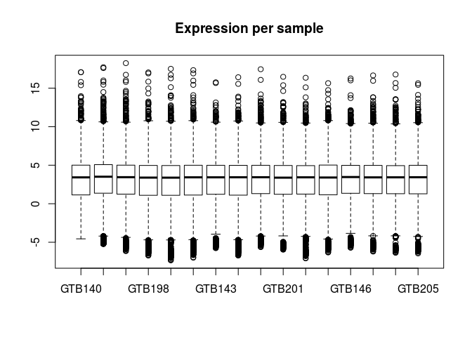

```r
boxplot(expr, main = "Expression per sample")
```

```r
multidensity(expr, main = "Densities of expression", legend = NULL)
```

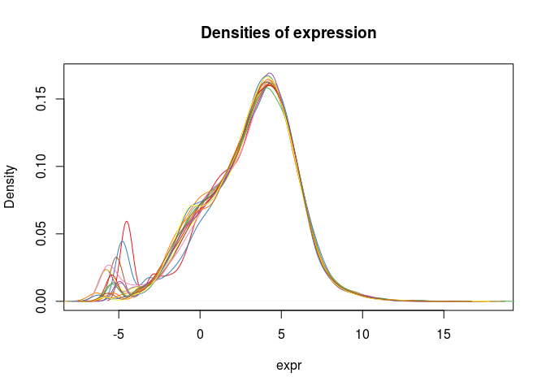

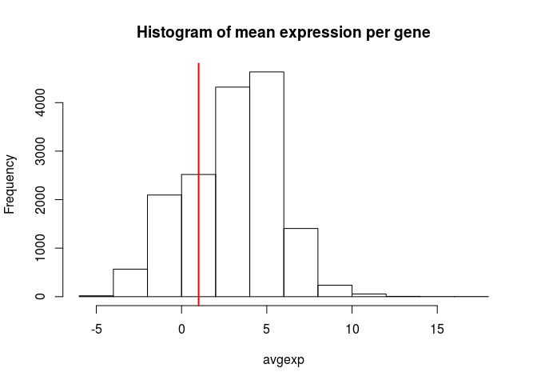

```r
avgexp <- rowMeans(expr)
hist(avgexp, main = "Histogram of mean expression per gene")
abline(v = 1, col = "red", lwd = 2)
```

We can observe that the densities differ between samples on the low expression values. We should filter those genes that are below 1, as they are unreliable.

```r
expr <- expr[avgexp > 1, ]
multidensity(expr, main = "Densities of expression", legend = NULL)
```

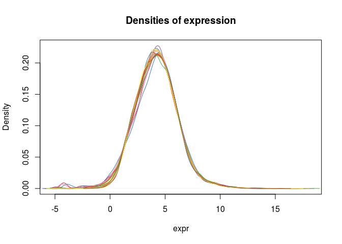

Now the distribution of the expression between samples is much more comparable. But it still has some perturbation at the peak of the the expression. Nevertheless, we create an Expression Set.

```r
DR <- ExpressionSet(as.matrix(expr))
phenoData(DR) <- AnnotatedDataFrame(pheno)
DR
```

```
## ExpressionSet (storageMode: lockedEnvironment)
## assayData: 12007 features, 16 samples
##   element names: exprs
## protocolData: none
## phenoData
##   rowNames: GTB140 GTB141 ... GTB205 (16 total)
##   varLabels: Fraction
##   varMetadata: labelDescription
## featureData: none
## experimentData: use 'experimentData(object)'
## Annotation:
```

## 2.3 Check normalizations

We plot it too the MDS, to see where our samples go

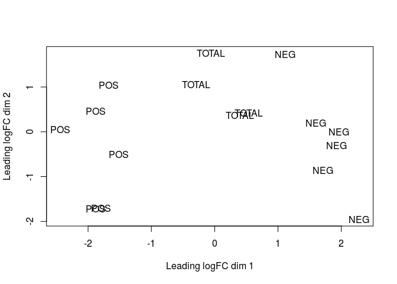

```r
plotMDS(DR, labels = phenoData(DR)$Fraction)
```

## 2.4 Design

In this case each type of expression has come from a different subset of the liver, so we should consider each one as an independent group.

```r
design3 <- model.matrix(~0 + phenoData(DR)$Fraction)
colnames(design3) <- substring(colnames(design3), 23)
design3
```

```
##    NEG POS TOTAL
## 1    0   1     0
## 2    0   1     0
## 3    0   1     0
## 4    0   1     0
## 5    0   1     0
## 6    0   1     0
## 7    1   0     0
## 8    1   0     0
## 9    1   0     0
## 10   1   0     0
## 11   1   0     0
## 12   1   0     0
## 13   0   0     1
## 14   0   0     1
## 15   0   0     1
## 16   0   0     1
## attr(,"assign")
## [1] 1 1 1
## attr(,"contrasts")
## attr(,"contrasts")$`phenoData(DR)$Fraction`
## [1] "contr.treatment"
```

We can fit our design to the expression data:

```r
fit3 <- lmFit(exprs(DR), design3)
```

## 2.5 Contrasts

We are interested in the Positive vs Negative comparison, but we can compute others too:

```r
contrasts2 <- makeContrasts("PosVsNegative" = POS - NEG,
                            "PosVsTotal" = POS - TOTAL,
                            "NegVsTotal" = NEG - TOTAL, levels = design3)
contrasts2
```

```
##        Contrasts
## Levels  PosVsNegative PosVsTotal NegVsTotal
##   NEG              -1          0          1
##   POS               1          1          0
##   TOTAL             0         -1         -1
```

```r
fit4 <- contrasts.fit(fit3, contrasts2)
fit4 <- eBayes(fit4, proportion = 0.18)
results.DR <- decideTests(fit4, adjust.method = "fdr", lfc = log2(2))
summary(results.DR)
```

```
##    PosVsNegative PosVsTotal NegVsTotal
## -1          1143        279         79
## 0           9822      11423      11928
## 1           1042        305          0
```

We can observe the quality of the t values over the teoretical quantiles to observe if there is any assumption about the eBayes fitting which doesn’t holds. Note that I already modified the expected proportion of genes in the call to eBayes:

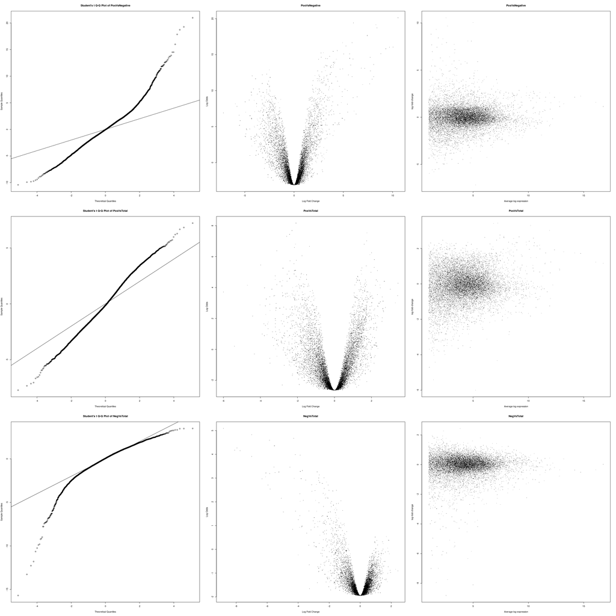

```r
par(mfrow = c(3, 3))
out <- sapply(colnames(results.DR), function(x){
  qqt(fit4$t[, x], df = fit4$df.total, main = paste("Student's t Q-Q Plot of", x))
  abline(0, 1)
  volcanoplot(fit4, coef = x, main = x)
  plotMD(fit4, coef = x, main = x)
})
```

## 2.6 Store the data

```r
save(fit3, fit4, design3, DR, contrasts2,  file = "DR.RData")
```

## 2.7 Differentially expressed genes

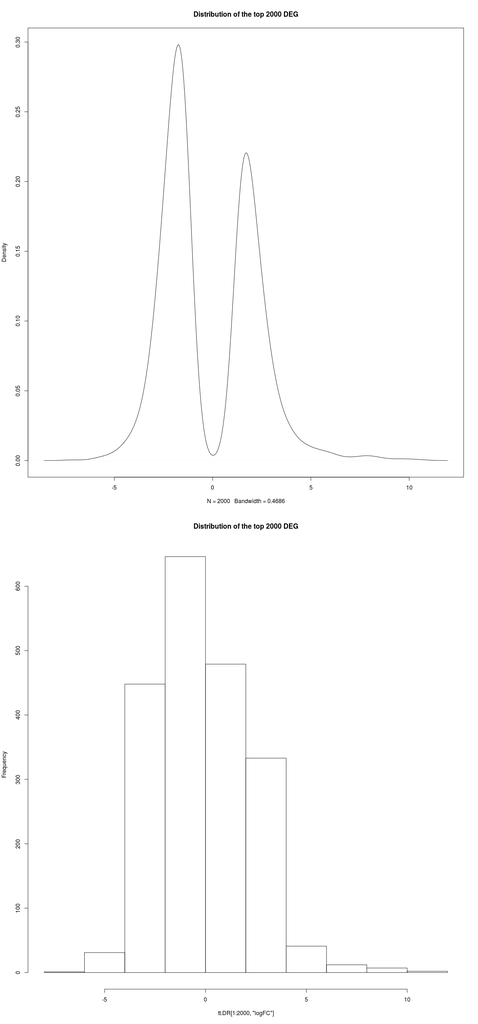

```r
tt.DR <- topTable(fit4, coef = "PosVsNegative", sort.by = "logFC", number = Inf)
tt.DR <- tt.DR[order(-abs(tt.DR$logFC)), ] # Ordered by the absolute value of logFC
par(mfrow = c(2, 1))
plot(density(tt.DR[1:2000, "logFC"]), main = "Distribution of the top 2000 DEG")
hist(tt.DR[1:2000, "logFC"], main = "Distribution of the top 2000 DEG")
```